# MB5370

### 2.22.2 Overriding defaults in ggplot2

```r
demo <- tribble(
  ~cut,         ~freq,
  "Fair",       1610,
  "Good",       4906,
  "Very Good",  12082,
  "Premium",    13791,
  "Ideal",      21551
)
demo
```

```
## # A tibble: 5 × 2
##   cut        freq
##   <chr>     <dbl>
## 1 Fair       1610
## 2 Good       4906
## 3 Very Good 12082
## 4 Premium   13791
## 5 Ideal     21551
```

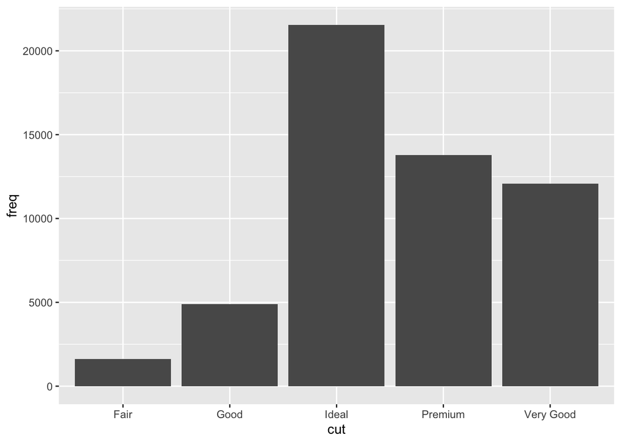

```r
ggplot(data = demo) +
  geom_bar(mapping = aes(x = cut, y = freq), stat = "identity")
```

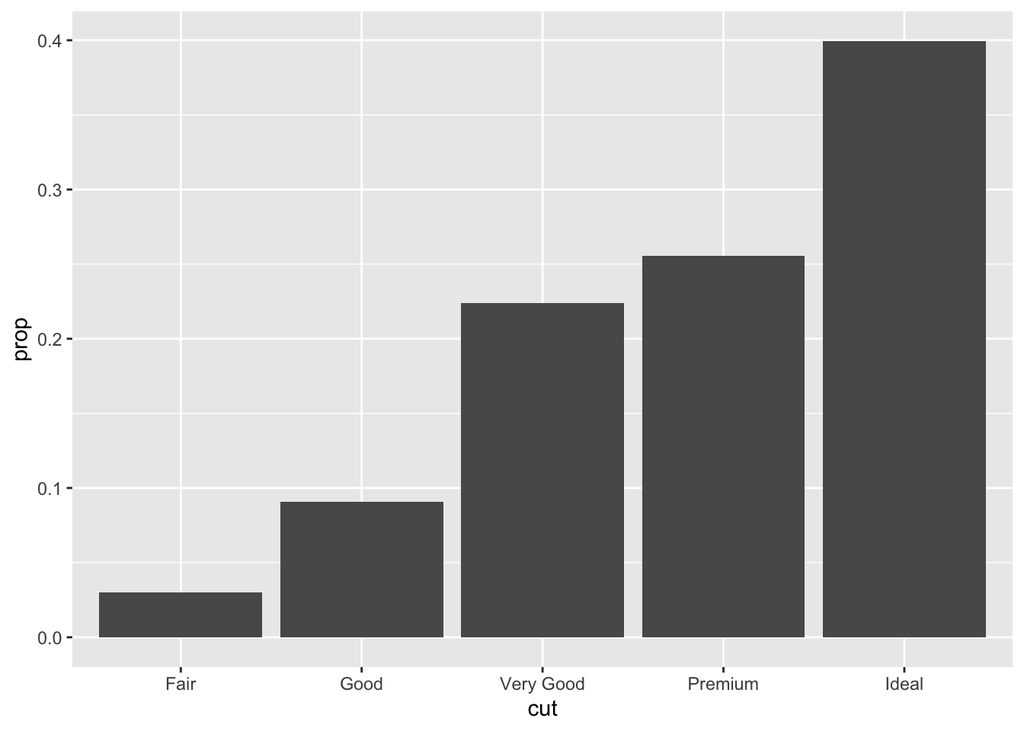

```r
#override a default mapping from transformed variables to aesthetics
ggplot(data = diamonds) +
  geom_bar(mapping = aes(x = cut, y = stat(prop), group = 1))
```

### 2.22.3 Plotting statistical details

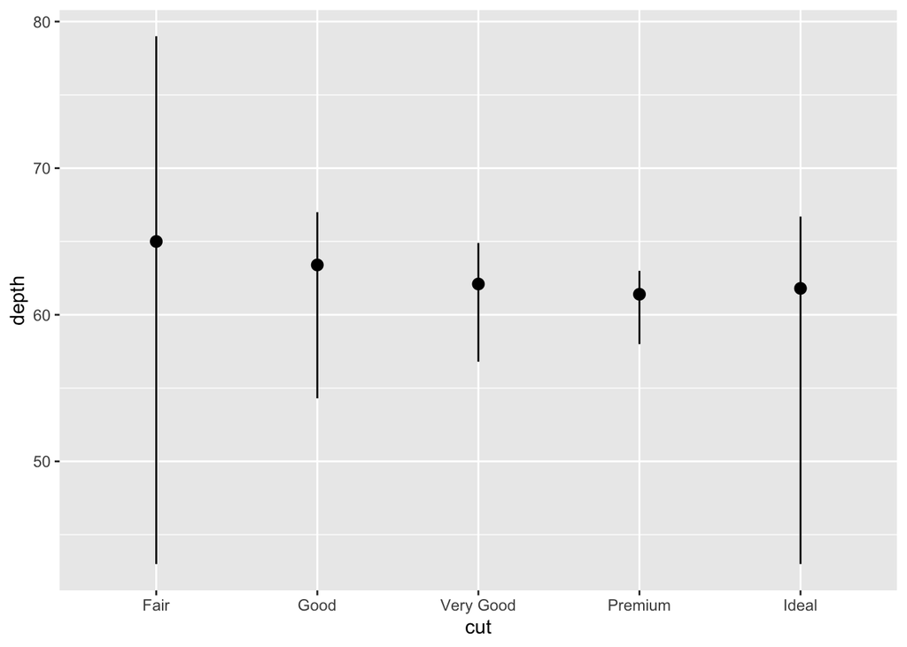

```r
ggplot(data = diamonds) +
  stat_summary(
    mapping = aes(x = cut, y = depth),
    fun.min = min,
    fun.max = max,
    fun = median
  )
```

## 2.23 Aesthetic adjustments

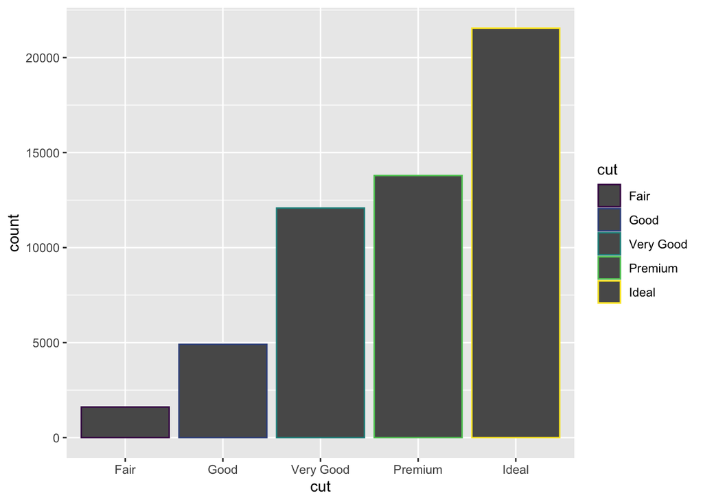

```r
ggplot(data = diamonds) +
  geom_bar(mapping = aes(x = cut, colour = cut))
```

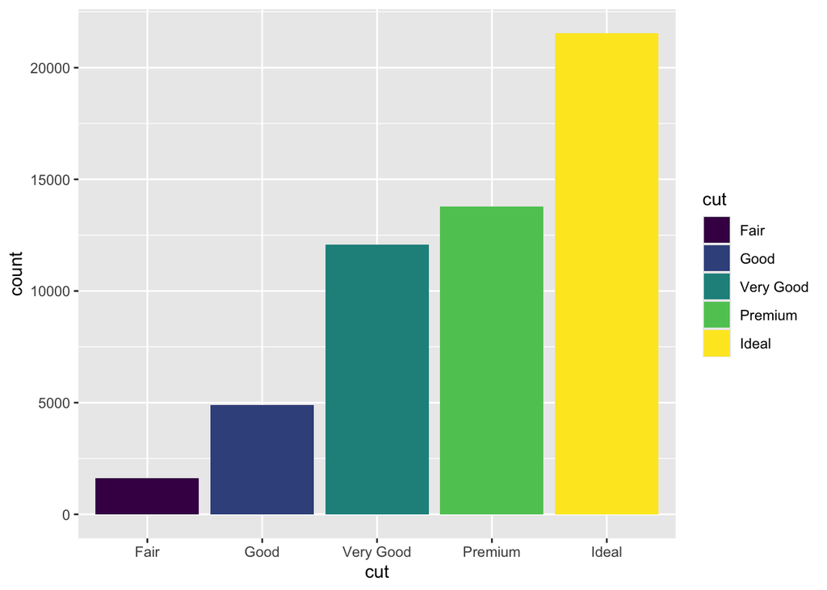

```r
ggplot(data = diamonds) +
  geom_bar(mapping = aes(x = cut, fill = cut))
```

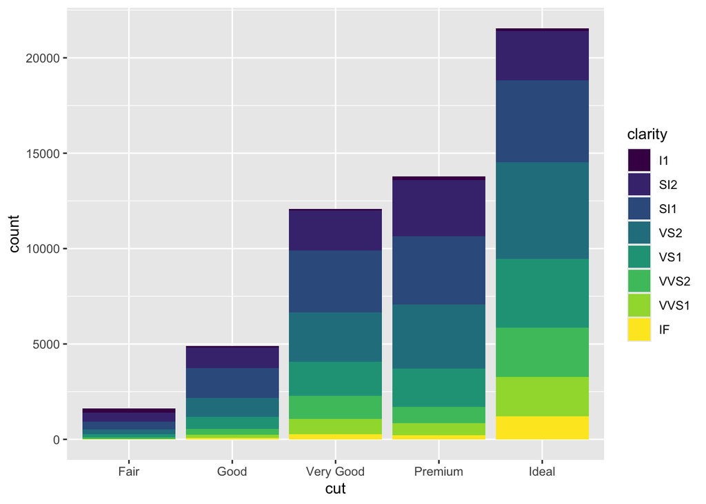

```r
#colour by another variable like clarity
ggplot(data = diamonds) +
  geom_bar(mapping = aes(x = cut, fill = clarity))
```

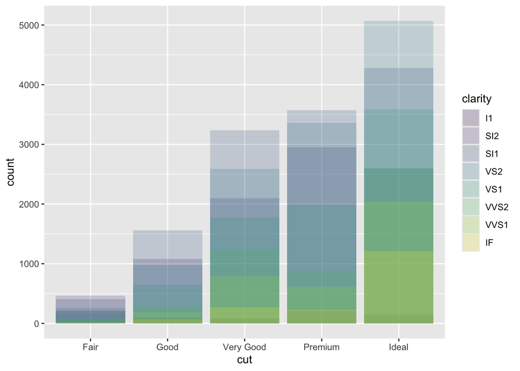

```r
#use position = "identity"
#To alter transparency (alpha)
ggplot(data = diamonds, mapping = aes(x = cut, fill = clarity)) +
  geom_bar(alpha = 1/5, position = "identity")
```

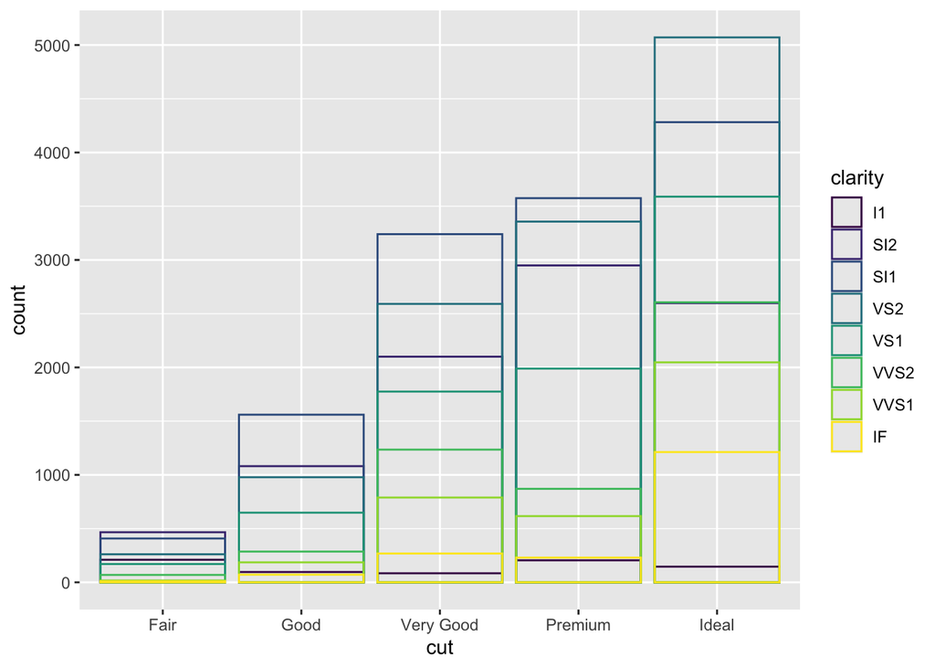

```r
#To color the bar outlines with no fill color
ggplot(data = diamonds, mapping = aes(x = cut, colour = clarity)) +
  geom_bar(fill = NA, position = "identity")
```

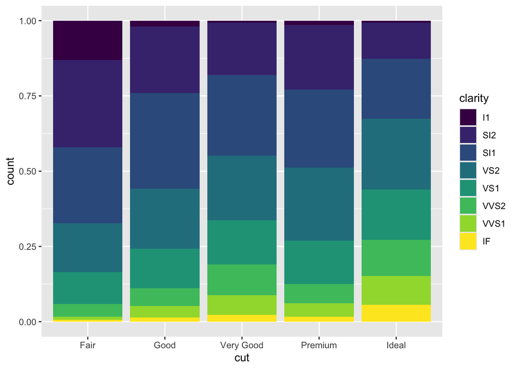

```r
#position = "fill"
ggplot(data = diamonds) +
  geom_bar(mapping = aes(x = cut, fill = clarity), position = "fill")
```

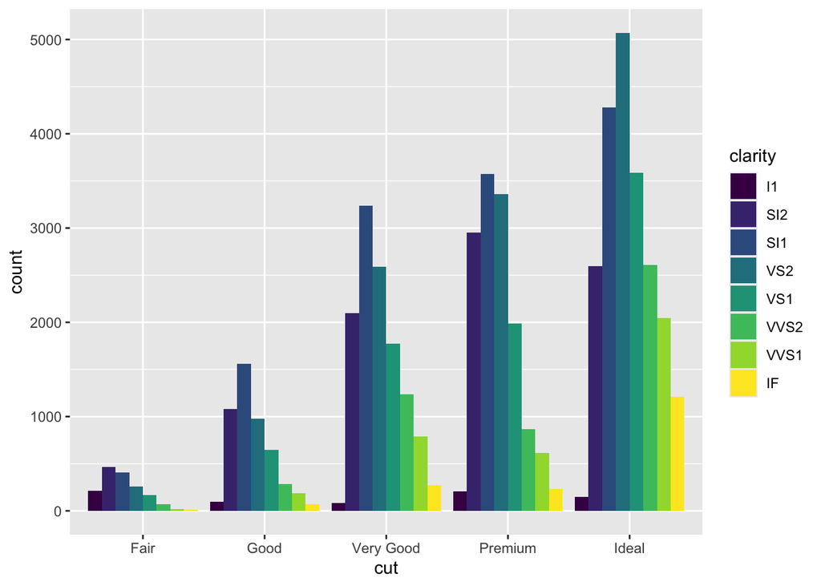

```r
#position = "dodge"
ggplot(data = diamonds) +
  geom_bar(mapping = aes(x = cut, fill = clarity), position = "dodge")
```

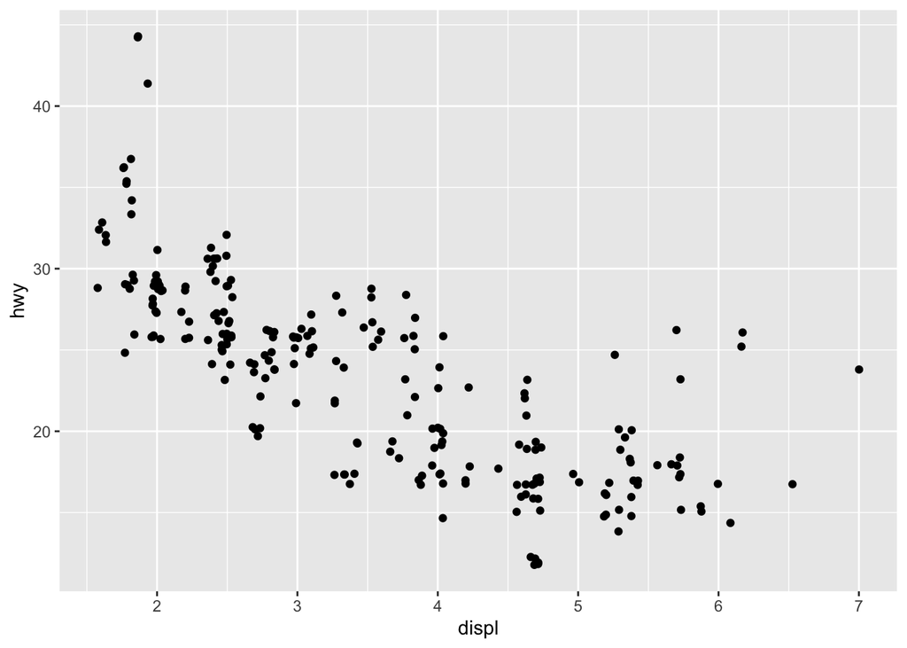

```r
#position = "jitter"
ggplot(data = mpg) +
  geom_point(mapping = aes(x = displ, y = hwy), position = "jitter")
```

# Workshop 4

The Developer’s Toolbox & AI

## 4.4 chattr (Conversational Workspace Engine)

```r
#install.packages("ellmer")
# install.packages("chattr")
```

### Exercise: Prompting for Context

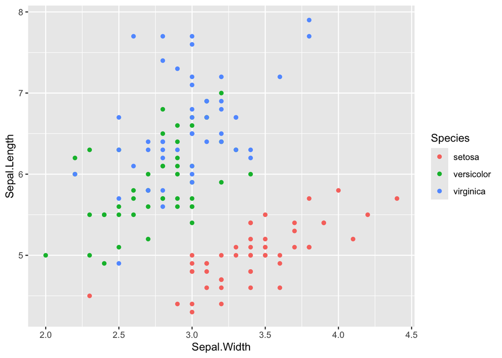

```r
library(ggplot2)

data(iris)

ggplot(iris, aes(x = Sepal.Width, y = Sepal.Length, color = Species)) +
  geom_point()
```

## 4.3 Conditional Logic - filtering your data

Base R: if and else

```r
# Simple Example: Checking Sea Surface Temperature (SST)
sst <- 30.2

if (sst > 29.5) {
  print("Warning: Marine heatwave threshold exceeded!")
} else {
  print("SST remains within baseline parameters.")
}
```

```
## [1] "Warning: Marine heatwave threshold exceeded!"
```

Tidyverse Alternative: Vectorised Conditionals (dplyr)

if_else()

```r
# Load tidyverse (if not already loaded)
library(tidyverse)

# Sample coral data
coral_monitoring <- tibble(
  site = c("Site_A", "Site_B", "Site_C"),
  depth_m = c(12, 35, 8)
)

# Classify depth using if_else
coral_monitoring <- coral_monitoring %>%
  mutate(zone = if_else(depth_m > 30, "Deep Reef", "Shallow Reef"))
```

what mutate() does? The mutate() function, from the dplyr package, is used to add new variables (columns) to a data frame or modify existing ones. It always operates on a data frame and returns a new data frame with the added or modified columns, while preserving existing columns.

what abou the %>% symbol? The %>% symbol is known as the pipe operator. It comes from the magrittr package, which is loaded as part of the tidyverse. Its primary purpose is to pass the result of the expression on its left-hand side as the first argument to the function on its right-hand side. This allows you to chain multiple operations together in a more readable and sequential manner, making your code flow from left to right, rather than nesting functions inside each other.

case_when()

```r
coral_monitoring <- coral_monitoring %>%
  mutate(reef_category = case_when(
    depth_m < 10  ~ "Lagoon / Flats",
    depth_m <= 30 ~ "Crest / Slope",
    depth_m > 30  ~ "Mesophotic / Deep",
    TRUE          ~ "Unclassified" # Catch-all remainder
  ))
```

task

```r
library(dplyr)

marine_stations <- tibble(
  salinity = c(35, 28, 32, 12)
) %>%
  mutate(
    environment_type = case_when(
      salinity < 15 ~ "Estuarine",
      salinity >= 15 & salinity <= 30 ~ "Brackish",
      salinity > 30 ~ "Marine",
      TRUE ~ NA_character_ # Optional: handles any other cases not explicitly covered
    )
  )

print(marine_stations)
```

```
## # A tibble: 4 × 2
##   salinity environment_type
##      <dbl> <chr>
## 1       35 Marine
## 2       28 Brackish
## 3       32 Marine
## 4       12 Estuarine
```

## 4.4 Automation — Iterating Efficiently

Base R: for-loops

```r
# Classic loop anatomy
for (year in 2020:2024) {
  print(paste("Processing climate data for year:", year))
}
```

```
## [1] "Processing climate data for year: 2020"
## [1] "Processing climate data for year: 2021"
## [1] "Processing climate data for year: 2022"
## [1] "Processing climate data for year: 2023"
## [1] "Processing climate data for year: 2024"
```

```r
# Loop across index sequences
transect_lengths <- c(50, 100, 25, 75)

for (i in seq_along(transect_lengths)) {
  print(paste("Transect number", i, "measures", transect_lengths[i], "metres."))
}
```

```
## [1] "Transect number 1 measures 50 metres."
## [1] "Transect number 2 measures 100 metres."
## [1] "Transect number 3 measures 25 metres."
## [1] "Transect number 4 measures 75 metres."
```

Tidyverse Alternative: Functional Programming (purrr) Comparison Example: Calculating Square Roots of Site Vectors Using a standard for-loop:

```r
site_areas <- c(144, 400, 625)
results <- numeric(length(site_areas)) # Must build an empty container first

for(i in seq_along(site_areas)) {
  results[i] <- sqrt(site_areas[i])
}
```

Using the purrr equivalent:

```r
library(purrr)
# Map directly and define your expected output type explicitly
mapped_results <- map_dbl(site_areas, sqrt)
```

Iterating Across Complex Groups

```r
# Iterate a summary function over split lists of data
iris %>%
  split(.$Species) %>%
  map(~summary(.x))
```

```
## $setosa
##   Sepal.Length    Sepal.Width     Petal.Length    Petal.Width
##  Min.   :4.300   Min.   :2.300   Min.   :1.000   Min.   :0.100
##  1st Qu.:4.800   1st Qu.:3.200   1st Qu.:1.400   1st Qu.:0.200
##  Median :5.000   Median :3.400   Median :1.500   Median :0.200
##  Mean   :5.006   Mean   :3.428   Mean   :1.462   Mean   :0.246
##  3rd Qu.:5.200   3rd Qu.:3.675   3rd Qu.:1.575   3rd Qu.:0.300
##  Max.   :5.800   Max.   :4.400   Max.   :1.900   Max.   :0.600
##        Species
##  setosa    :50
##  versicolor: 0
##  virginica : 0
##
##
##
##
## $versicolor
##   Sepal.Length    Sepal.Width     Petal.Length   Petal.Width          Species
##  Min.   :4.900   Min.   :2.000   Min.   :3.00   Min.   :1.000   setosa    : 0
##  1st Qu.:5.600   1st Qu.:2.525   1st Qu.:4.00   1st Qu.:1.200   versicolor:50
##  Median :5.900   Median :2.800   Median :4.35   Median :1.300   virginica : 0
##  Mean   :5.936   Mean   :2.770   Mean   :4.26   Mean   :1.326
##  3rd Qu.:6.300   3rd Qu.:3.000   3rd Qu.:4.60   3rd Qu.:1.500
##  Max.   :7.000   Max.   :3.400   Max.   :5.10   Max.   :1.800
##
## $virginica
##   Sepal.Length    Sepal.Width     Petal.Length    Petal.Width
##  Min.   :4.900   Min.   :2.200   Min.   :4.500   Min.   :1.400
##  1st Qu.:6.225   1st Qu.:2.800   1st Qu.:5.100   1st Qu.:1.800
##  Median :6.500   Median :3.000   Median :5.550   Median :2.000
##  Mean   :6.588   Mean   :2.974   Mean   :5.552   Mean   :2.026
##  3rd Qu.:6.900   3rd Qu.:3.175   3rd Qu.:5.875   3rd Qu.:2.300
##  Max.   :7.900   Max.   :3.800   Max.   :6.900   Max.   :2.500
##        Species
##  setosa    : 0
##  versicolor: 0
##  virginica :50
##
##
##
```

Task using chattr:

```r
library(purrr) # For map_dbl()

# List of fish count data
fish_counts_list <- list(
  site_a = c(10, 12, 8, 15, 11),
  site_b = c(25, 20, 22, 18),
  site_c = c(5, 7, 6)
)

# Using a for-loop
mean_counts_for_loop <- vector("numeric", length = length(fish_counts_list))
names(mean_counts_for_loop) <- names(fish_counts_list)

for (i in seq_along(fish_counts_list)) {
  mean_counts_for_loop[i] <- mean(fish_counts_list[[i]])
}

print("Mean counts (for-loop):")
```

```
## [1] "Mean counts (for-loop):"
```

```r
print(mean_counts_for_loop)
```

```
## site_a site_b site_c
##  11.20  21.25   6.00
```

```r
# Using purrr's map_dbl()
mean_counts_map_dbl <- map_dbl(fish_counts_list, mean)

print("Mean counts (map_dbl):")
```

```
## [1] "Mean counts (map_dbl):"
```

```r
print(mean_counts_map_dbl)
```

```
## site_a site_b site_c
##  11.20  21.25   6.00
```

## 4.5 Writing custom functions

Function Construction Blueprint

```r
# Function Definition
calculate_coral_mortality <- function(initial_count, surviving_count) {

  # Logic safety switch using our conditional tools!
  if (initial_count <= 0) {
    stop("Initial count must be greater than zero.")
  }

  mortality_rate <- (initial_count - surviving_count) / initial_count
  return(mortality_rate)
}

# Utilizing your custom function
calculate_coral_mortality(initial_count = 120, surviving_count = 84)
```

```
## [1] 0.3
```

Student Exercise 4: Custom Function Construction Task

```r
#create a function to convert temperature in C° to F°
convert_temp_c_to_f <- function(temp_C){
  #make a safety check to prevent temperatures below absolute zero
  if (temp_C < -273.15){
    stop("Entered value is below absolute zero (-273.15 degrees Celsius)")
  }
  temp_F <- (temp_C * 9/5) + 32
  return(temp_F)
}
#test function
convert_temp_c_to_f(temp_C = 25)
```

```
## [1] 77
```

```r
#convert_temp_c_to_f(temp_C = -300)
```

## 4.6 Advanced Scripting Extension Challenges

Challenge 1: Nested Multi-Vector Iteration

```r
survey_counts <- c(15, 24, 8, 42)
species_specific_scaling_factors <- c(1.2, 0.8, 2.5, 1.1)

purrr::map2_dbl(survey_counts,species_specific_scaling_factors, `*`)
```

```
## [1] 18.0 19.2 20.0 46.2
```

Challenge 2: The Robust Data Wrangling Pipeline Function

```r
#Create a custom function
clean_and_classify_survey <- function(df, col_name, threshold_parameter){
  #Safely check if the specified column name exists
  if (!col_name %in% names(df)){
    stop("Entered column ", col_name, " not found.")
  }
  #filter out NA values and mutate based on threshold
  cleaned_df <- df %>%
                  filter_out(is.na(!!sym(col_name))) %>%
                          mutate(status_classification = case_when(
                            col_name < threshold_parameter ~ "Fail",
                            col_name >= threshold_parameter ~ "Pass"
                          ))
  return(cleaned_df)
}

#tests
#1
test1 <- tibble(Names = c("A", "B", "C", "D", "E", "F", "G", "H", "I", "J"),
                Grade = c(56, 78, 42, 90, 87, 38, 67, 75, 2, 52))
clean_and_classify_survey(test1, "Grade", 50)
```

```
## # A tibble: 10 × 3
##    Names Grade status_classification
##    <chr> <dbl> <chr>
##  1 A        56 Pass
##  2 B        78 Pass
##  3 C        42 Pass
##  4 D        90 Pass
##  5 E        87 Pass
##  6 F        38 Pass
##  7 G        67 Pass
##  8 H        75 Pass
##  9 I         2 Pass
## 10 J        52 Pass
```

```r
#2 (NA values)
test2 <- tibble(Names = c("A", "B", "C", "D", "E", "F", "G", "H", "I", "J"),
                Grade = c(56, 78, 42, 90, NA, 38, 67, 75, 2, NA))
clean_and_classify_survey(test2, "Grade", 50)
```

```
## # A tibble: 8 × 3
##   Names Grade status_classification
##   <chr> <dbl> <chr>
## 1 A        56 Pass
## 2 B        78 Pass
## 3 C        42 Pass
## 4 D        90 Pass
## 5 F        38 Pass
## 6 G        67 Pass
## 7 H        75 Pass
## 8 I         2 Pass
```